# Winter 2025 Final Assessment

Author

# Introduction

This assessment is designed as a practice of several analyses we have covered throughout the semester. Each example will give background for the research questions.

You are responsible for determining the appropriate alternative hypothesis for each question **based on context**. Unless otherwise specified, use $\alpha = 0.05$.

Do all work **ON YOUR OWN**.

You may use class notes and assignments but not internet searches, Artificial Intelligence or other people.

Don’t forget to load the libraries.

# Diet and Exercise

A health nutritionist wanted to study the effects of three different diets on people’s ability to run a mile. He randomly chose 43 individuals who were willing to participate in the study and randomly assigned them to be fed a certain kind of diet. After two weeks of being on the diet, each person ran a mile and the time it took to run a mile was recorded.

## Load the Data

```r
running <- import('https://github.com/byuistats/Math221D_Cannon/raw/master/Data/Running.xlsx') %>% mutate(Diet = factor(Diet))
View(running)
```

**QUESTION**: What is the explanatory variable?  
**ANSWER**: diet

## Visualization

Create a side-by-side boxplot using `ggplot()`. Be sure to give it a title. Color the boxes based on Diet.

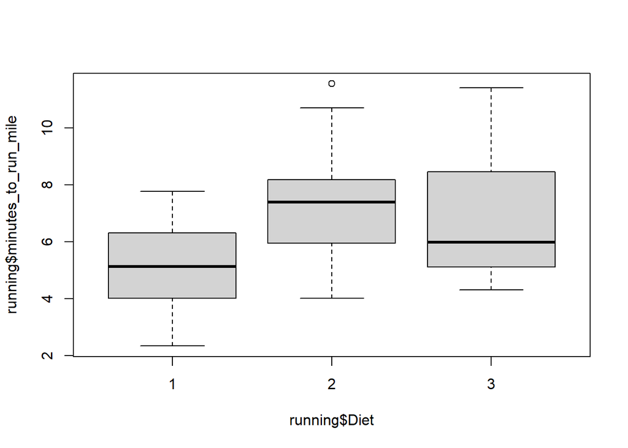

```r
boxplot(running$minutes_to_run_mile ~ running$Diet)
```

## Hypothesis Test

**QUESTION**: What type of test is appropriate for this data?  
**ANSWER**: ANOVA to test for variance

**QUESTION**: State your null and alternative hypotheses:

Ho: u1 = u2 = u3 Ha: There is at least one u different alpha: 0.05

Perform the appropriate test to determine if diet has any effect on the time it takes individuals to run a mile.

```r
sds <- favstats(running$minutes_to_run_mile ~ running$Diet)$sd
max(sds) / min(sds)
```

```
[1] 1.565944
```

```r
running_auth_aov <- aov(running$minutes_to_run_mile ~ running$Diet)
summary(running_auth_aov)
```

```
             Df Sum Sq Mean Sq F value  Pr(>F)
running$Diet  2  49.34   24.67   6.375 0.00395 **
Residuals    40 154.81    3.87
---
Signif. codes:  0 '***' 0.001 '**' 0.01 '*' 0.05 '.' 0.1 ' ' 1
```

**Question**: What is the P-value?  
**Answer**: 0.00395

**QUESTION**: State your conclusion. Include the technical (decision based on P-value and alpha) and the contextual conclusion.  
**ANSWER**: the P-value is less than an alpha of 0.05, therefore there is enough evidence to reject the null and conclude that there is an variance between runned miles by diets.

### Test Requirements

Check all the requirements for the appropriateness of the statistical test:

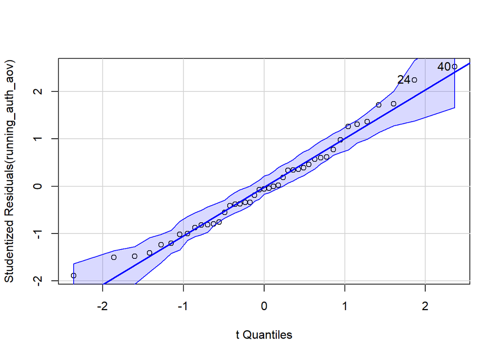

```
[1] 24 40
```

```r
qqPlot(running_auth_aov)
```

**QUESTION**: Explain each of the requirements and whether or not they are satisfied.  
**ANSWER**: independence, subjects were randomly assigned, therefore is met and bias is reduced.

Normality: The qqPlot displays that the values are normally distributed, therefore the results aren’t skewed.

# Location, Location, Location!

## Load the Data

```r
apartments <- import('https://github.com/byuistats/Math221D_Cannon/raw/master/Data/Appartments.xlsx')
View(apartments)
```

**QUESTION**: What is the response variable?  
**ANSWER**: price of an apartment

**QUESTION**: What is the explanatory variable?  
**ANSWER**: how far the house is from downtown

## Visualization

Use `ggplot()` to create a scatter plot with a regression line.

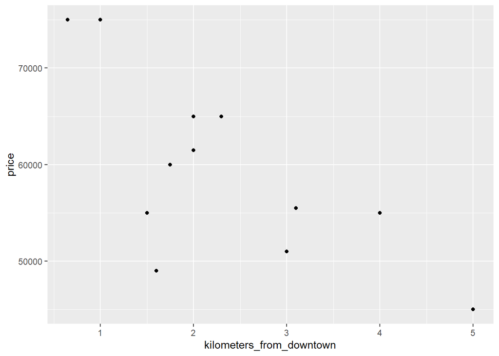

```r
ggplot(apartments, mapping = aes(x = kilometers_from_downtown, y = price)) + geom_point()
```

**QUESTION**: Does the relationship between x and y appear roughly linear?  
**ANSWER**: Yes, even though there aren’t many data points you could draw a line representing the pattern.

**QUESTION**: What is the correlation coefficient?  
**ANSWER**: -0.7100981

```r
cor(apartments$price ~ apartments$kilometers_from_downtown,data = apartments)
```

```
[1] -0.7100981
```

**QUESTION**: Describe in words what the correlation coefficient shows us about this relationship?  
**ANSWER**: There appears to be a strong and negative linear relationship between price and distance. In other words, the further the apartment is from downtown, the lower the price tends to be.

## Hypothesis Test

**QUESTION**: State the null and alternative hypotheses for the relevant statistical test:

Ho: B1 = 0 Ha: B1 != 0

Perform the appropriate analysis:

```r
out <- lm(apartments$price ~ apartments$kilometers_from_downtown)
summary(out)
```

```
Call:
lm(formula = apartments$price ~ apartments$kilometers_from_downtown)

Residuals:
     Min       1Q   Median       3Q      Max
-14232.9  -2995.3    376.9   4890.1   8539.8

Coefficients:
                                    Estimate Std. Error t value Pr(>|t|)
(Intercept)                            71839       4414  16.275 1.59e-08 ***
apartments$kilometers_from_downtown    -5379       1686  -3.189  0.00967 **
---
Signif. codes:  0 '***' 0.001 '**' 0.01 '*' 0.05 '.' 0.1 ' ' 1

Residual standard error: 7020 on 10 degrees of freedom
Multiple R-squared:  0.5042,    Adjusted R-squared:  0.4547
F-statistic: 10.17 on 1 and 10 DF,  p-value: 0.009667
```

**Question**: What is the P-value?  
**Answer**: 0.009667

**QUESTION**: State your conclusion. Include the technical (decision based on P-value and alpha) and the contextual conclusion.  
**ANSWER**: The p-value is smaller than an alpha of 0.05, therefore, there is enough evidence to reject the null and conclude that there is an negative linear relationship between price and distance.

**QUESTION**: Interpret the slope of the regression line *in context of the research question*.  
**ANSWER**: the further the apartment is from downtown, the lower the price tends to be.

**QUESTION**: Interpret the intercept of the regression line *in context of the research question*.  
**ANSWER**: prices of apartments close to downtown tend to cost above 70000 dollars.

## Confidence Interval

Create a confidence interval for the slope.

```r
confint(out, level = 0.95)
```

```
                                        2.5 %    97.5 %
(Intercept)                         62003.941 81673.835
apartments$kilometers_from_downtown -9136.587 -1620.879
```

**QUESTION**: Interpret the confidence interval for the slope in context of the research question.  
**ANSWER**: I have 95% confidece that the true price of the apartment tend to decrease whitin(-9136.587 and -1620.879) dollars per every kilometer traveled.

### Test Requirements

Check all the requirements for the appropriateness of the analysis.

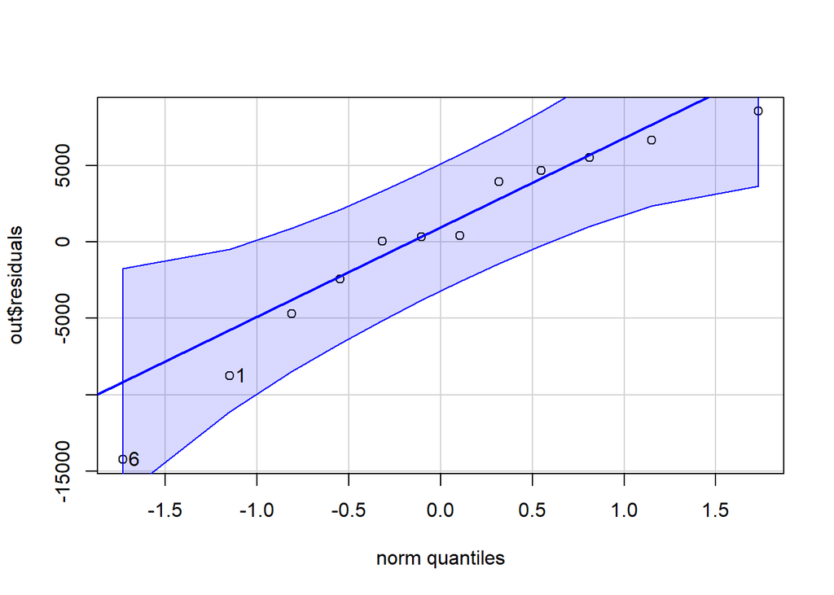

```
[1] 6 1
```

```r
qqPlot(out$residuals)
```

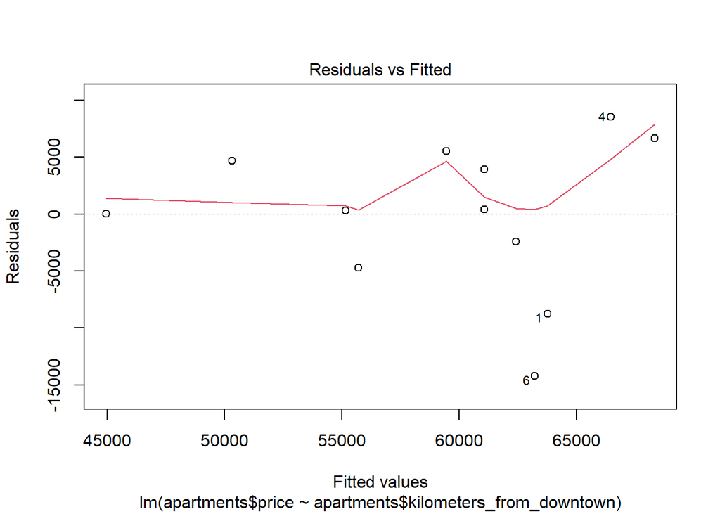

```r
plot(out, which = 1)
```

**QUESTION**: Explain each of the requirements and whether or not they are satisfied.  
**ANSWER**: Normality: qqPlot checks if the data is normal to avoid skewed results, of which is met. Linearity: Checks the relationship between price and distance to see discrepancies in correlations, of which is met.

# Ahhh choo!

```r
cough <- import('https://raw.githubusercontent.com/byuistats/Math221D_Cannon/refs/heads/master/Data/cough_relief.csv')# %>% mutate(Relief = factor(Relief, levels = c("No relief", "Some relief", "Complete relief")))
View(cough)
```

## Clean the Data

Create a clean dataset that removes any missing values from Relief and Remedy columns:

```r
clean <- cough %>%
  select(Relief, Remedy) %>%
  filter(!Relief %in% "",
         !Remedy %in% "") %>%
  group_by(Relief, Remedy) %>%
  summarise(count = n())
View(clean)
```

## Visualization

Use `ggplot()` and the clean dataset to create a bar chart that groups bars by remedy and has different colors for each of the levels of relief:

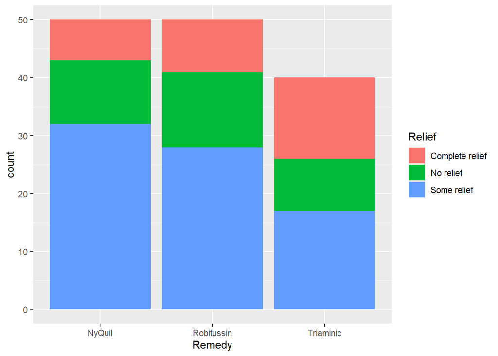

```r
ggplot(clean, mapping = aes(x = Remedy, y = count, fill = Relief)) + geom_col()
```

## Summary Statistics

Create a contingency table of counts for Relief by Remedy.

```r
contingency_table <- xtabs(count ~ Relief + Remedy, data = clean)
contingency_table
```

```
                 Remedy
Relief            NyQuil Robitussin Triaminic
  Complete relief      7          9        14
  No relief           11         13         9
  Some relief         32         28        17
```

Create a proportion table for the percent of Relief for the different types of Remedies. (Proportions should sum to 1 for each Remedy type.)

```r
prop_tab <- prop.table(contingency_table, margin = 2) * 100
prop_tab
```

```
                 Remedy
Relief            NyQuil Robitussin Triaminic
  Complete relief   14.0       18.0      35.0
  No relief         22.0       26.0      22.5
  Some relief       64.0       56.0      42.5
```

**QUESTION**: Which remedy has the highest proportion of Complete Relief?  
**ANSWER**: Triaminic

**QUESTION**: What is the proportion of respondents who felt Complete Relief from taking NyQuil?  
**ANSWER**: 14%

## Hypothesis Test

Perform a Chi-square test of independence.

**QUESTION**: State the Null and Alternative Hypotheses.

Ho: relief is independent from remedy Ha: relief is not independent from remedy

Perform the appropriate analysis:

```r
chisq.test(contingency_table)
```

```
    Pearson's Chi-squared test

data:  contingency_table
X-squared = 7.0788, df = 4, p-value = 0.1318
```

**Question**: What is the P-value?  
**Answer**: 0.1318

**QUESTION**: State your conclusion. Include the technical (decision based on P-value and alpha) and the contextual conclusion.  
**ANSWER**: The p-value is not smaller than an alpha of 0.05, therefore we fail to reject the null, and cannot conclude the remedy taken does not appear to significantly affect how much relief a person experiences.

### Test Requirements

Check the requirements for the appropriateness of the Chi-square test:

```r
chisq.test(contingency_table)$expected >= 5
```

```
                 Remedy
Relief            NyQuil Robitussin Triaminic
  Complete relief   TRUE       TRUE      TRUE
  No relief         TRUE       TRUE      TRUE
  Some relief       TRUE       TRUE      TRUE
```

**QUESTION**: Are the requirements satisfied?  
**ANSWER**: Yes, we can expect all the row totals to be proportionally distributed across the column groups.